# Logistic Regression

## Importing the libraries

```python
import numpy as np
import matplotlib.pyplot as plt
import pandas as pd
```

## Importing the dataset

```python
dataset = pd.read_csv('Social_Network_Ads.csv')
```

```python
dataset.head()
```

|  | Age | EstimatedSalary | Purchased |
| --- | --- | --- | --- |
| 0 | 19 | 19000 | 0 |
| 1 | 35 | 20000 | 0 |
| 2 | 26 | 43000 | 0 |
| 3 | 27 | 57000 | 0 |
| 4 | 19 | 76000 | 0 |

```python
X = dataset.iloc[:, :-1].values   # declaring feature matrix
y = dataset.iloc[:, -1].values    # declaring target varibale
```

## Splitting the dataset into the Training set and Test set

```python
from sklearn.model_selection import train_test_split

X_train, X_test, y_train, y_test = train_test_split(X, y, test_size = 0.25, random_state = 0)
```

```python
# print(X_train)
```

```python
print(len(y_train))
```

```
300
```

```python
print(len(X_test))
```

```
100
```

```python
print(len(y_test))
```

```
100
```

## Feature Scaling

```python
from sklearn.preprocessing import StandardScaler

sc = StandardScaler()
X_train = sc.fit_transform(X_train)
X_test = sc.transform(X_test)
```

```python
# print(X_train)
```

```python
# print(X_test)
```

## Training the Logistic Regression model on the Training set

```python
from sklearn.linear_model import LogisticRegression

classifier = LogisticRegression(random_state = 0) # instanciating

classifier.fit(X_train, y_train)  #fitting logistic regression
```

```
LogisticRegression(random_state=0)
```

## Predicting a new result

```python
print(classifier.predict(sc.transform([[37,67000]])))
```

```
[0]
```

## Predicting the Test set results

```python
y_pred = classifier.predict(X_test)
```

```python
y_pred
```

```
array([0, 0, 0, 0, 0, 0, 0, 1, 0, 1, 0, 0, 0, 0, 0, 0, 0, 0, 1, 0, 0, 1,
       0, 1, 0, 1, 0, 0, 0, 0, 0, 0, 1, 0, 0, 0, 0, 0, 0, 1, 0, 0, 0, 0,
       1, 0, 0, 1, 0, 1, 1, 0, 0, 0, 1, 0, 0, 0, 0, 0, 0, 1, 0, 0, 0, 1,
       0, 0, 0, 0, 1, 0, 0, 0, 0, 0, 1, 0, 1, 1, 1, 1, 0, 0, 1, 1, 0, 1,
       0, 0, 0, 1, 0, 0, 0, 0, 0, 0, 1, 1], dtype=int64)
```

```python
# print(np.concatenate((y_pred.reshape(len(y_pred),1), y_test.reshape(len(y_test),1)),1))
```

## Making the Confusion Matrix

**NOTE:**

- A confusion matrix can be used to visualize true and false positives and negatives. The rows of the matrix are the true classes of the instances, and the columns are the predicted classes of the instances.
- When creating a confusion matrix it is important to understand and maintain a convention for which differentiating positive and negative label values. The usual convention is to call the $1$ case positive and the $0$ case negative.

```python
from sklearn.metrics import confusion_matrix

cm = confusion_matrix(y_test, y_pred)
print(cm)
```

```
[[65  3]
 [ 8 24]]
```

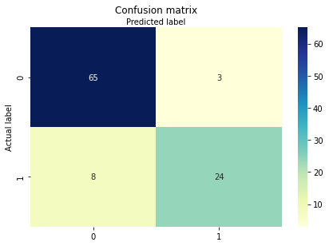

```python
import matplotlib.pyplot as plt
import seaborn as sns

class_names=[0,1] # name  of classes

fig, ax = plt.subplots()
tick_marks = np.arange(len(class_names))
plt.xticks(tick_marks, class_names)
plt.yticks(tick_marks, class_names)

# create heatmap
sns.heatmap(pd.DataFrame(cm), annot=True, cmap="YlGnBu" ,fmt='g')
ax.xaxis.set_label_position("top")
plt.tight_layout()
plt.title('Confusion matrix', y=1.1)
plt.ylabel('Actual label')
plt.xlabel('Predicted label')
```

The confusion matrix indicates that there were 65 true negative predictions, 24 true positive predictions, 8 false negative predictions, and 3 false positive prediction.

## Model Evaluation

**Accuracy**

Accuracy is a simple and often misused metric. In simple terms, accuracy is the fraction of cases correctly classified. For a two-class classifier accuracy is written as:

$$Accuracy = \frac{TP+TN}{TP+FP+TN+FN}$$

Accuracy is simply the ratio of total number of correct predictions and total number of predictions.

**Precision**

Precision is the fraction of correctly classified label cases out of all cases classified with that label value. We can express precision by the following relationship:

$$Precision = \frac{TP}{TP+FP}$$

In other words, the precision statistic is the number of correctly classified cases for the label value divided by all the cases in the column. Thus, precision is sensitive to the number of cases correctly classified for a given score value.

**Recall**

Recall is the fraction of cases of a label value correctly classified out of all cases that actually have that label value. We can express recall by the following relationship:

$$Recall = \frac{TP}{TP+FN}$$

In other words, the recall statistic is the number of correctly classified cases for the label value divided by all the cases in the row. Thus, precision is sensitive to the number of cases correctly classified for a given true label value.

**F1**

The F1 statistic is weighted average of precision and recall. We can express F1 by the following relationship:

$$F1 = 2 * \frac{precision * recall}{precision + recall}$$

In other words, F1 is a weighted metric for overall model performance.

```python
from sklearn import metrics

print("Accuracy:",metrics.accuracy_score(y_test, y_pred))
print("Precision:",metrics.precision_score(y_test, y_pred))
print("Recall:",metrics.recall_score(y_test, y_pred))
print("f1:",metrics.f1_score(y_test,y_pred))
```

```
Accuracy: 0.89
Precision: 0.8888888888888888
Recall: 0.75
f1: 0.8135593220338982
```

```python
from sklearn import metrics

# View summary of common classification metrics

print("---Metrices---")
print(metrics.classification_report(y_true = y_test, y_pred = y_pred))
```

```
---Metrices---
              precision    recall  f1-score   support

           0       0.89      0.96      0.92        68
           1       0.89      0.75      0.81        32

    accuracy                           0.89       100
   macro avg       0.89      0.85      0.87       100
weighted avg       0.89      0.89      0.89       100
```

```python
from sklearn.metrics import roc_curve, auc

#---find the predicted probabilities using the test set
probs = classifier.predict_proba(X_test)
preds = probs[:,1]

#---find the FPR, TPR, and threshold---
fpr, tpr, threshold = roc_curve(y_test, preds)
```

```python
print(threshold)
```

```
[1.99605114e+00 9.96051142e-01 9.80797629e-01 9.77519656e-01
 5.44777116e-01 5.04204559e-01 4.75162380e-01 4.64479680e-01
 4.37030330e-01 4.03071099e-01 3.91088701e-01 3.34937347e-01
 3.21125912e-01 2.94100575e-01 2.92991355e-01 2.76956114e-01
 2.55305539e-01 8.92901563e-02 8.39193352e-02 2.75596617e-02
 2.62494857e-02 1.85335995e-03]
```

```python
print(fpr)
```

```
[0.         0.         0.         0.01470588 0.01470588 0.04411765
 0.04411765 0.05882353 0.05882353 0.10294118 0.10294118 0.14705882
 0.14705882 0.17647059 0.17647059 0.22058824 0.22058824 0.41176471
 0.41176471 0.64705882 0.67647059 1.        ]
```

```python
print(tpr)
```

```
[0.      0.03125 0.1875  0.1875  0.75    0.75    0.8125  0.8125  0.84375
 0.84375 0.875   0.875   0.90625 0.90625 0.9375  0.9375  0.96875 0.96875
 1.      1.      1.      1.     ]
```

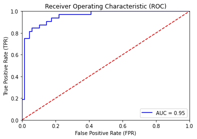

```python
#---find the area under the curve---

roc_auc = auc(fpr, tpr)

import matplotlib.pyplot as plt
plt.plot(fpr, tpr, 'b', label = 'AUC = %0.2f' % roc_auc)
plt.plot([0, 1], [0, 1],'r--')
plt.xlim([0, 1])
plt.ylim([0, 1])
plt.ylabel('True Positive Rate (TPR)')
plt.xlabel('False Positive Rate (FPR)')
plt.title('Receiver Operating Characteristic (ROC)')
plt.legend(loc = 'lower right')
plt.show()
```

## Plotting Decision Boundary

```python
## install mlxtend library

# !pip install mlxtend
```

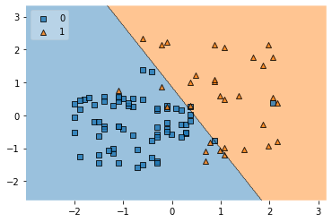

```python
import matplotlib.pyplot as plt
from mlxtend.plotting import plot_decision_regions
# import matplotlib.gridspec as gridspec
%matplotlib inline

plot_decision_regions(X=X_test, y=y_test, clf=classifier, legend=2)
```